# Homework 3

John Duncan Hurt

May 3, 2020

#### ANT 388 (Applied Data Analysis) Spring 2020

## Challenge 1

#### Part 1

##### Setting up

```r
library(tidyverse)
library(broom)
library(infer)
library(boot)

d0 <- read_csv("https://raw.githubusercontent.com/difiore/ADA-datasets/master/KamilarAndCooperData.csv")
d0
```

```
## # A tibble: 213 x 44
##    Scientific_Name Family Genus Species Brain_Size_Spec~ Brain_Size_Fema~
##    <chr>           <chr>  <chr> <chr>              <dbl>            <dbl>
##  1 Allenopithecus~ Cerco~ Alle~ nigrov~             58.0             53.7
##  2 Allocebus_tric~ Cerco~ Allo~ tricho~             NA               NA
##  3 Alouatta_belze~ Ateli~ Alou~ belzeb~             52.8             51.2
##  4 Alouatta_caraya Ateli~ Alou~ caraya              52.6             47.8
##  5 Alouatta_guari~ Ateli~ Alou~ guariba             51.7             49.1
##  6 Alouatta_palli~ Ateli~ Alou~ pallia~             49.9             48.0
##  7 Alouatta_pigra  Ateli~ Alou~ pigra               51.1             48.8
##  8 Alouatta_senic~ Ateli~ Alou~ senicu~             55.2             54.3
##  9 Aotus_azarai    Cebid~ Aotus azarai              20.7             20.7
## 10 Aotus_brumbacki Cebid~ Aotus brumba~             NA               NA
## # ... with 203 more rows, and 38 more variables: Brain_size_Ref <chr>,
## #   Body_mass_male_mean <dbl>, Body_mass_female_mean <dbl>,
## #   Mass_Dimorphism <dbl>, Mass_Ref <chr>, MeanGroupSize <dbl>,
## #   AdultMales <dbl>, AdultFemale <dbl>, AdultSexRatio <dbl>,
## #   Social_Organization_Ref <chr>, InterbirthInterval_d <dbl>, Gestation <dbl>,
## #   WeaningAge_d <dbl>, MaxLongevity_m <dbl>, LitterSz <dbl>,
## #   Life_History_Ref <chr>, GR_MidRangeLat_dd <dbl>, Precip_Mean_mm <dbl>,
## #   Temp_Mean_degC <dbl>, AET_Mean_mm <dbl>, PET_Mean_mm <dbl>,
## #   Climate_Ref <chr>, HomeRange_km2 <dbl>, HomeRangeRef <chr>,
## #   DayLength_km <dbl>, DayLengthRef <chr>, Territoriality <dbl>, Fruit <dbl>,
## #   Leaves <chr>, Fauna <chr>, DietRef1 <chr>, Canine_Dimorphism <dbl>,
## #   Canine_Dimorphism_Ref <chr>, Feed <dbl>, Move <dbl>, Rest <dbl>,
## #   Social <dbl>, Activity_Budget_Ref <chr>
```

```r
#We know the two variables we will be working with. Do they have any NAs?

any(is.na(d0[["Brain_Size_Species_Mean"]])) | any(is.na(d0[["MaxLongevity_m"]]))
```

```
## [1] TRUE
```

```r
#The lm() function and our plotting functions should omit NA cases by default. But I like to just remove them from the data beforehand if they're going to be excluded; that way there is no ambiguity about how they will be handled.

d <- filter(d0, !is.na(d0[["MaxLongevity_m"]]) & !is.na(d0[["Brain_Size_Species_Mean"]]))
```

##### Now, we will be creating two regression models: one with the variables untransformed (referred to as Model 1 or ‘mod’) and another with the variables log-transformed (referred to as Model 2 or ‘logmod’). Below we create the first linear regression model object, ‘mod’. We then create a dataframe ‘modtext’, whose elements will tell the geom_text() function what we want to write on the plot and where we want that writing to appear. Finally, we create the plot object.

```r
#First model

mod <- lm(MaxLongevity_m ~ Brain_Size_Species_Mean, data = d)
summary(mod)
```

```
##
## Call:
## lm(formula = MaxLongevity_m ~ Brain_Size_Species_Mean, data = d)
##
## Residuals:
##     Min      1Q  Median      3Q     Max
## -198.27  -61.92  -17.78   56.16  331.36
##
## Coefficients:
##                         Estimate Std. Error t value Pr(>|t|)
## (Intercept)             248.9523    11.1111   22.41   <2e-16 ***
## Brain_Size_Species_Mean   1.2180     0.1101   11.06   <2e-16 ***
## ---
## Signif. codes:  0 '***' 0.001 '**' 0.01 '*' 0.05 '.' 0.1 ' ' 1
##
## Residual standard error: 90.91 on 126 degrees of freedom
## Multiple R-squared:  0.4928, Adjusted R-squared:  0.4887
## F-statistic: 122.4 on 1 and 126 DF,  p-value: < 2.2e-16
```

```r
#Creating the plot

modtext <- data.frame(
  a = 180,
  b = 850,
  c = paste(sep = "",
            "y = ",
            round(mod$coefficients, 2)[1],
            " + ",
            round(mod$coefficients, 2)[2],
            "x"
            )        )

modplot <- ggplot(d, aes(x = Brain_Size_Species_Mean, y = MaxLongevity_m)) +
  geom_point() +
  geom_smooth(method = "lm", se = FALSE) +
  geom_text(data = modtext, mapping = aes(x = a, y = b, label = c)) +
  labs(x = "Brain Size", y = "Longevity") +
  ggtitle("Model 1")
```

```r
#Second model

logmod <- lm(log(MaxLongevity_m) ~ log(Brain_Size_Species_Mean), data = d)
summary(logmod)
```

```
##
## Call:
## lm(formula = log(MaxLongevity_m) ~ log(Brain_Size_Species_Mean),
##     data = d)
##
## Residuals:
##     Min      1Q  Median      3Q     Max
## -0.6955 -0.1750 -0.0097  0.1788  0.6084
##
## Coefficients:
##                              Estimate Std. Error t value Pr(>|t|)
## (Intercept)                   4.87895    0.06907   70.63   <2e-16 ***
## log(Brain_Size_Species_Mean)  0.23415    0.01781   13.15   <2e-16 ***
## ---
## Signif. codes:  0 '***' 0.001 '**' 0.01 '*' 0.05 '.' 0.1 ' ' 1
##
## Residual standard error: 0.2485 on 126 degrees of freedom
## Multiple R-squared:  0.5784, Adjusted R-squared:  0.5751
## F-statistic: 172.9 on 1 and 126 DF,  p-value: < 2.2e-16
```

```r
#Creating the plot

logmodtext <- data.frame(
  a = 2.5,
  b = 6.6,
  c = paste(sep = "",
            "y = ",
            round(logmod$coefficients, 2)[1],
            " + ",
            round(logmod$coefficients, 2)[2],
            "x"
            )           )

logmodplot <- ggplot(d, aes(x = log(Brain_Size_Species_Mean), y = log(MaxLongevity_m))) +
  geom_point() +
  geom_smooth(method = "lm", se = FALSE) +
  geom_text(data = logmodtext, mapping = aes(x = a, y = b, label = c)) +
  labs(x = "log(Brain Size)", y = "log(Longevity)") +
  ggtitle("Model 2")
```

##### Printing our two plots to complete the first step of Challenge 1

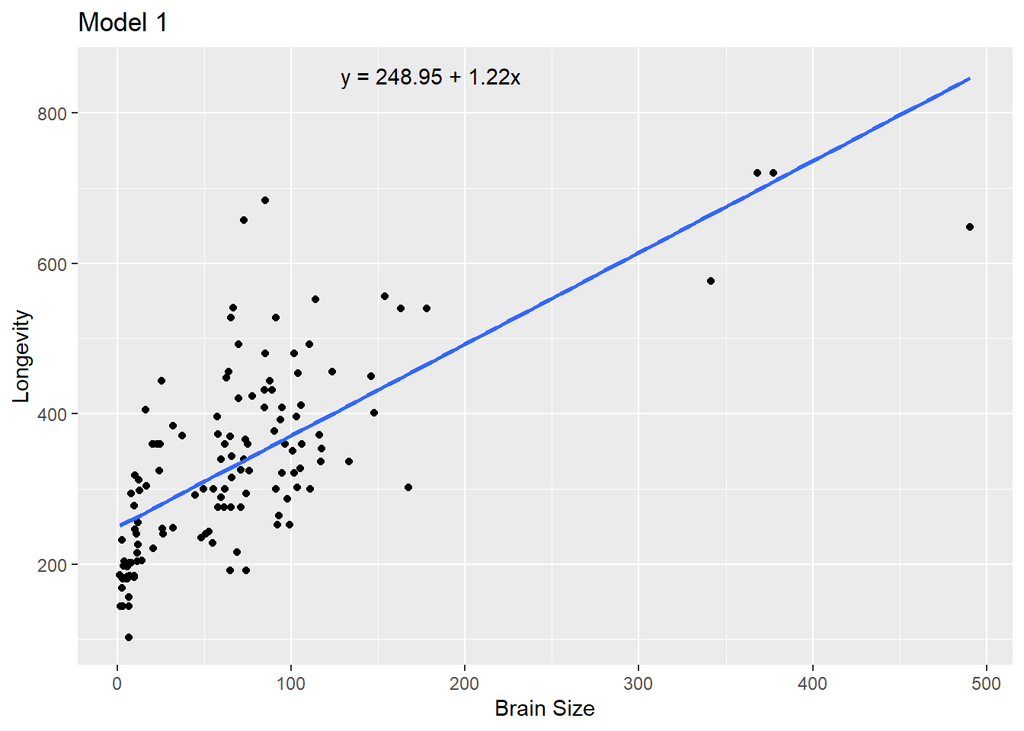

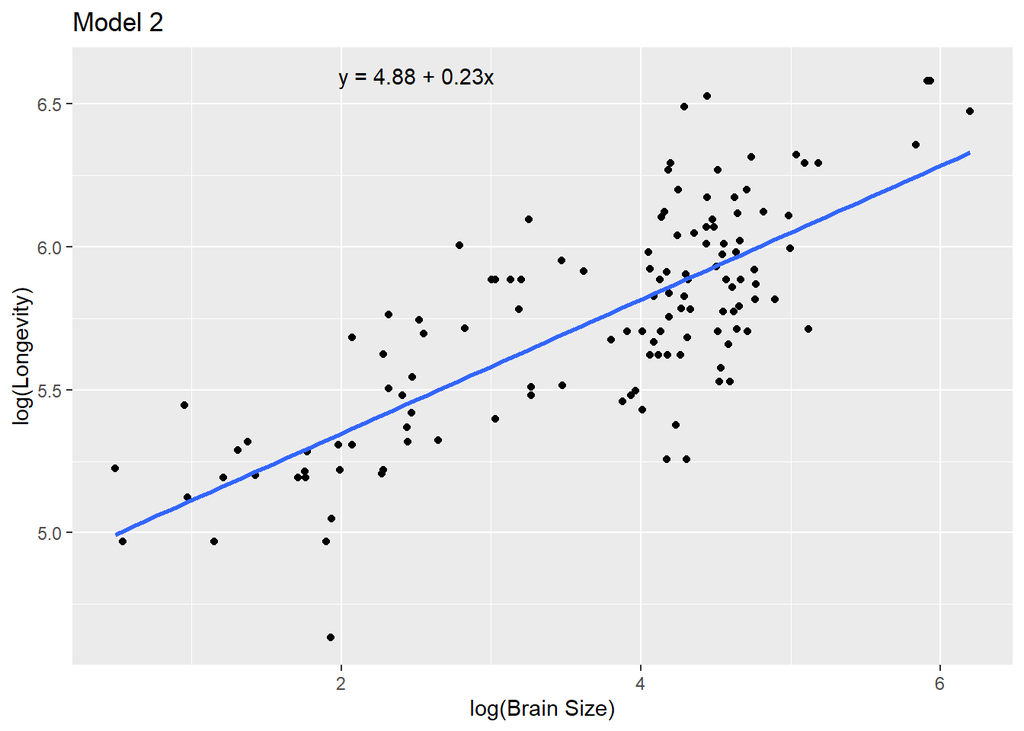

### Part 2

##### We can see already from the text on our plots that the slope coefficient for Model 1 is 1.22, and the slope coefficient for Model 2 is 0.23. (Recall that the only difference between Model 1 and Model 2 is that the x and y values were log-transformed in the latter and not in the former). This refutes the null hypothesis that the slope coefficient (Beta1) is zero, confirming the alternative hypothesis that the slope coefficient is not zero. The 90% CI for the slope coefficient of each model is calculated below.

```r
#CI of Beta1 for Model 1
confint(mod, "Brain_Size_Species_Mean", level = 0.90)
```

```
##                              5 %    95 %
## Brain_Size_Species_Mean 1.035571 1.40041
```

```r
#CI of Beta1 for Model 2
confint(logmod, "log(Brain_Size_Species_Mean)", level = 0.90)
```

```
##                                    5 %      95 %
## log(Brain_Size_Species_Mean) 0.2046396 0.2636595
```

### Part 3

```r
#We need to create 8 new variables in order to plot the CI and PI for both models.

d2 <- select(d, Scientific_Name, Brain_Size_Species_Mean, MaxLongevity_m)

modfitCI <- predict(mod, interval = "conf", level = 0.90)
modfitPI <- predict(mod, interval = "predict", level = 0.90)

d2 <- mutate(d2, modCIlwr = modfitCI[, "lwr"], modCIupr = modfitCI[, "upr"])
d2 <- mutate(d2, modPIlwr = modfitPI[, "lwr"], modPIupr = modfitPI[, "upr"])

logmodfitCI <- predict(logmod, interval = "conf", level = 0.90)
logmodfitPI <- predict(logmod, interval = "predict", level = 0.90)

d2 <- mutate(d2, logmodCIlwr = logmodfitCI[, "lwr"], logmodCIupr = logmodfitCI[, "upr"])
d2 <- mutate(d2, logmodPIlwr = logmodfitPI[, "lwr"], logmodPIupr = logmodfitPI[, "upr"])

d2
```

```
## # A tibble: 128 x 11
##    Scientific_Name Brain_Size_Spec~ MaxLongevity_m modCIlwr modCIupr modPIlwr
##    <chr>                      <dbl>          <dbl>    <dbl>    <dbl>    <dbl>
##  1 Allenopithecus~            58.0            276      306.     333.     168.
##  2 Alouatta_caraya            52.6            244.     299.     327.     162.
##  3 Alouatta_palli~            49.9            300      296.     324.     158.
##  4 Alouatta_pigra             51.1            240      297.     325.     160.
##  5 Alouatta_senic~            55.2            300      303.     330.     165.
##  6 Aotus_azarai               20.7            360      258.     290.     123.
##  7 Aotus_lemurinus            16.3            406.     252.     285.     117.
##  8 Aotus_trivirga~            16.8            304.     253.     286.     118.
##  9 Arctocebus_cal~             6.92           156      240.     275.     106.
## 10 Ateles_belzebu~           117.             336      376.     407.     240.
## # ... with 118 more rows, and 5 more variables: modPIupr <dbl>,
## #   logmodCIlwr <dbl>, logmodCIupr <dbl>, logmodPIlwr <dbl>, logmodPIupr <dbl>
```

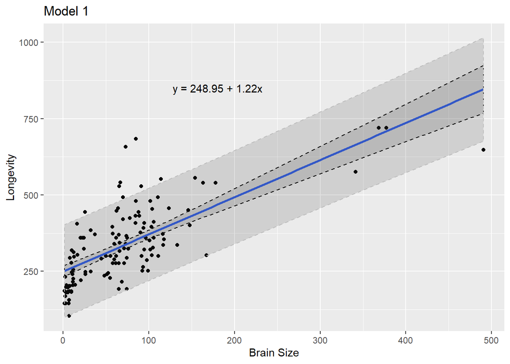

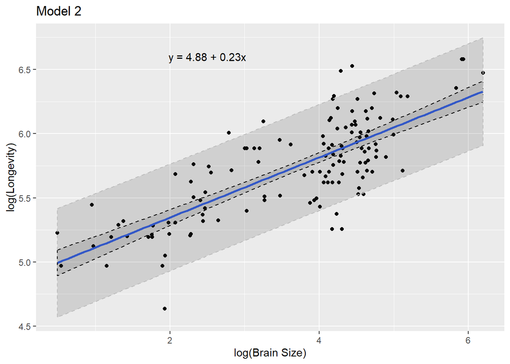

```r
#Now, we are finally ready to creat our new plot objects

modplot2 <- ggplot(d2, aes(x = Brain_Size_Species_Mean, y = MaxLongevity_m)) +
  geom_point() +
  geom_smooth(method = "lm", se = FALSE) +
  geom_text(data = modtext, mapping = aes(x = a, y = b, label = c)) +
  labs(x = "Brain Size", y = "Longevity") +
  ggtitle("Model 1") +
  geom_ribbon(aes(ymin = modCIlwr, ymax = modCIupr), alpha = 0.15, color = "black", linetype = "dashed") +
  geom_ribbon(aes(ymin = modPIlwr, ymax = modPIupr), alpha = 0.15, color = "grey", linetype = "dashed")




logmodplot2 <- ggplot(d2, aes(x = log(Brain_Size_Species_Mean), y = log(MaxLongevity_m))) +
  geom_point() +
  geom_smooth(method = "lm", se = FALSE) +
  geom_text(data = logmodtext, mapping = aes(x = a, y = b, label = c)) +
  labs(x = "log(Brain Size)", y = "log(Longevity)") +
  ggtitle("Model 2") +
  geom_ribbon(aes(ymin = logmodCIlwr, ymax = logmodCIupr), alpha = 0.15, color = "black", linetype = "dashed") +
  geom_ribbon(aes(ymin = logmodPIlwr, ymax = logmodPIupr), alpha = 0.15, color = "grey", linetype = "dashed")
```

### Part 4

##### Below we calculate the yhat value when x (Brain Size) is 750, along with the 90% prediction interval associated with this value of x. I do not really trust the model to make accurate predictions for this value of x because it exceeds the maximum range of the dataset used to create the model by a fair amount.

```r
predict(mod, newdata = data.frame(Brain_Size_Species_Mean = 750), interval = "predict", level = 0.90)
```

```
##        fit      lwr      upr
## 1 1162.445 966.8151 1358.075
```

### Part 5

##### I think Model 2 (‘logmod’) might be better just because log-transforming the data makes both variables more normally distributed, whereas prior to transformation they were both skewed (especially Brain_Size). The transformation thus makes the distribution of x and y values easier to visualize. The R2 value for ‘logmod’ is also slightly higher (0.578) than the R2 value for ‘mod’ (0.493), which reflects a better fit for Model 2.

## Challenge 2

### Part 1

```r
#Again, removing cases with NA values in the variables of interest

d3 <- filter(d0, !is.na(d0[["HomeRange_km2"]]) & !is.na(d0[["Body_mass_female_mean"]]))



#Running our new regression model

mod3 <- lm(log(HomeRange_km2) ~ log(Body_mass_female_mean), data = d3)
summary(mod3)
```

```
##
## Call:
## lm(formula = log(HomeRange_km2) ~ log(Body_mass_female_mean),
##     data = d3)
##
## Residuals:
##     Min      1Q  Median      3Q     Max
## -3.3929 -0.9433 -0.0126  1.0944  3.6826
##
## Coefficients:
##                            Estimate Std. Error t value Pr(>|t|)
## (Intercept)                -9.44123    0.67293  -14.03   <2e-16 ***
## log(Body_mass_female_mean)  1.03643    0.08488   12.21   <2e-16 ***
## ---
## Signif. codes:  0 '***' 0.001 '**' 0.01 '*' 0.05 '.' 0.1 ' ' 1
##
## Residual standard error: 1.423 on 135 degrees of freedom
## Multiple R-squared:  0.5248, Adjusted R-squared:  0.5213
## F-statistic: 149.1 on 1 and 135 DF,  p-value: < 2.2e-16
```

```r
#So, our Beta coefficients are...

paste("Intercept = ", mod3$coefficients[1], ", Slope = ", mod3$coefficients[2], sep = "")
```

```
## [1] "Intercept = -9.44123135615299, Slope = 1.03643151454044"
```

### Part 2

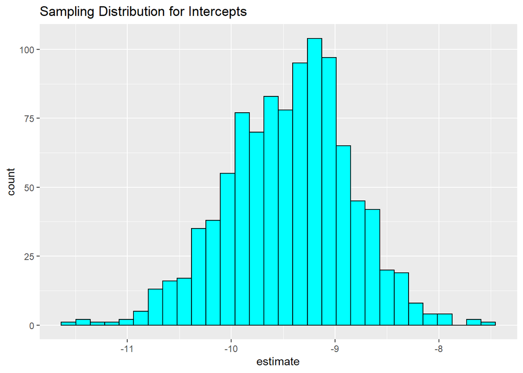

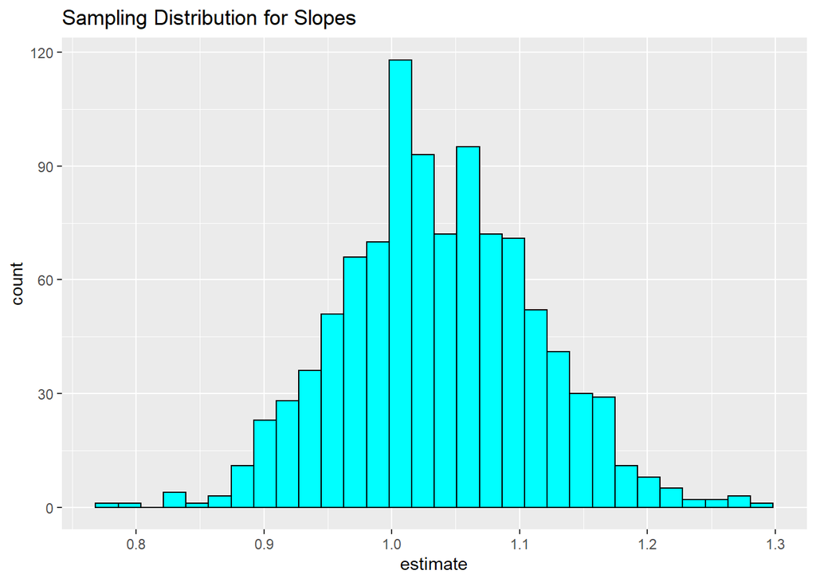

```r
#doing 1000 samples of size nrow(d0)
s <- rep_sample_n(d3, size = nrow(d3), reps = 1000, replace = TRUE)

#running linear regression on every sample
  s %>%
  group_by(replicate) %>%
  do(lm(log(HomeRange_km2) ~ log(Body_mass_female_mean), data = .) %>%
  tidy()) -> smod

#making two separate tibbles, one for all Beta0s and another for all Beta1s
  smodInt <- filter(smod, term == "(Intercept)")
  smodSlop <- filter(smod, term == "log(Body_mass_female_mean)")

#making the histogram for Beta0s
  smodIntPlot <- ggplot(smodInt, aes(x = estimate)) +
  geom_histogram(color = "black", fill = "cyan") +
  ggtitle("Sampling Distribution for Intercepts")


#and again for Beta1s
  smodSlopPlot <- ggplot(smodSlop, aes(x = estimate)) +
  geom_histogram(color = "black", fill = "cyan") +
  ggtitle("Sampling Distribution for Slopes")
```

### Part 3

```r
#taking the SD of the Beta0 coefficient to obtain the SE
 sd(smodInt[["estimate"]])
```

```
## [1] 0.5907485
```

```r
#taking the SD of the Beta1 coefficient to obtain the SE
 sd(smodSlop[["estimate"]])
```

```
## [1] 0.07593614
```

### Part 4

```r
#CI of the Beta0 coefficient (intercept) based on our bootstrapped sampling distribution
paste(quantile(smodInt$estimate, 0.025), quantile(smodInt$estimate, 0.975), sep = ", ")
```

```
## [1] "-10.658026061862, -8.3407620121527"
```

```r
#CI of the Beta1 coefficient (slope) based on our bootstrapped sampling distribution
paste(quantile(smodSlop$estimate, 0.025), quantile(smodSlop$estimate, 0.975), sep = ", ")
```

```
## [1] "0.895351851079549, 1.18388541142024"
```

### Part 6

```r
confint(mod3, "(Intercept)", level = 0.95)
```

```
##                 2.5 %    97.5 %
## (Intercept) -10.77209 -8.110374
```

```r
confint(mod3, "log(Body_mass_female_mean)", level = 0.95)
```

```
##                                2.5 %   97.5 %
## log(Body_mass_female_mean) 0.8685707 1.204292
```